# Дискриминантный анализ

Sazykin Dmitrii

27 ноября 2017 г

## Данные

Измерения геометрических свойств ядер трех разных сортов пшеницы. [Ссылка на источник](https://archive.ics.uci.edu/ml/datasets/seeds#).

Пример исследуемых объектов

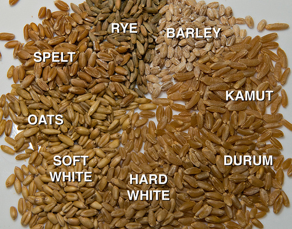

Для построения признаков были использованы следующие параметры ядер пшеницы

1. area A,
2. perimeter P,
3. compactness C = 4*pi*A/P^2,
4. length of kernel,
5. width of kernel,
6. asymmetry coefficient
7. length of kernel groove.

Описательная статистика по группам и matrixplot.

```
##
##  Descriptive statistics by group
## group: 1
##    vars  n  mean   sd   min   max range   se
## V1    1 70 14.33 1.22 11.23 17.08  5.85 0.15
## V2    2 70 14.29 0.58 12.63 15.46  2.83 0.07
## V3    3 70  0.88 0.02  0.84  0.92  0.08 0.00
## V4    4 70  5.51 0.23  4.90  6.05  1.15 0.03
## V5    5 70  3.24 0.18  2.85  3.68  0.83 0.02
## V6    6 70  2.67 1.17  0.77  6.68  5.92 0.14
## V7    7 70  5.09 0.26  4.52  5.88  1.36 0.03
## --------------------------------------------------------
## group: 2
##    vars  n  mean   sd   min   max range   se
## V1    1 70 18.33 1.44 15.38 21.18  5.80 0.17
## V2    2 70 16.14 0.62 14.66 17.25  2.59 0.07
## V3    3 70  0.88 0.02  0.85  0.91  0.07 0.00
## V4    4 70  6.15 0.27  5.36  6.67  1.31 0.03
## V5    5 70  3.68 0.19  3.23  4.03  0.80 0.02
## V6    6 70  3.64 1.18  1.47  6.68  5.21 0.14
## V7    7 70  6.02 0.25  5.14  6.55  1.41 0.03
## --------------------------------------------------------
## group: 3
##    vars  n  mean   sd   min   max range   se
## V1    1 70 11.87 0.72 10.59 13.37  2.78 0.09
## V2    2 70 13.25 0.34 12.41 13.95  1.54 0.04
## V3    3 70  0.85 0.02  0.81  0.90  0.09 0.00
## V4    4 70  5.23 0.14  4.90  5.54  0.64 0.02
## V5    5 70  2.85 0.15  2.63  3.23  0.60 0.02
## V6    6 70  4.79 1.34  1.66  8.46  6.80 0.16
## V7    7 70  5.12 0.16  4.75  5.49  0.75 0.02
```

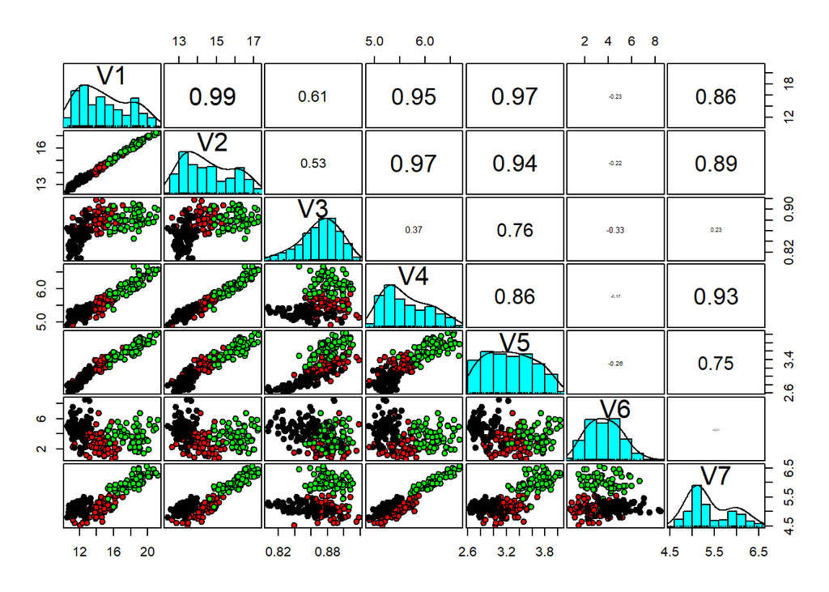

Распределение признаков не самое лучшее, также данные сильно скоррелированны (что неудивительно, так как все признаки описывают в каком-то смысле размеры ядрышка, кроме признака V6). Отметим наличие сбалансированного дизайна.

## LDA

Сначала немного про MANOVA.

Общая постановка задачи. Пусть есть k групп и p признаков, мы пытаемся проверить, что группы друг от друга не отличаются. Формально есть k (многомерных) случайных векторов $\eta_1,\ldots,\eta_k\in\mathrm R ^p$. Предполагается, что $\mathcal P (\eta_i) = \mathcal N (a_i,\Sigma)$. Тогда

$$\mathrm H_0:\, \mu_1=\ldots = \mu_k ;$$

эквивалентно этому можно рассмотреть

$$\mathrm H_0 : \mathrm E(\eta|\xi=A_1) = \ldots= \mathrm E(\eta|\xi=A_k) .$$

Обозначим

$$\mathbf E :=\widehat{ \mathrm E[(\eta - \mathrm E(\eta|\xi))(\eta - \mathrm E(\eta|\xi))^\mathrm T]}
= \sum_{i=1}^k \sum_{j=1}^{n_i} (y_{ij} - \mathbf{ \bar y_i})(y_{ij} - \mathbf{ \bar y_i})^\mathrm T;$$

$$\mathbf H :=\widehat{ \mathrm E[(\mathrm E(\eta|\xi)-\mathrm E \eta)(\mathrm E(\eta|\xi)-\mathrm E \eta)^\mathrm T]}
= \sum_{i=1}^k n_i (\mathbf{\bar y_i - \bar y})(\mathbf{\bar y_i - \bar y})^\mathrm T$$

и $s=\min(k-1,p)$.

Тогда статистика критерия MANOVA

1. Lambda Wilks’s

$$t = \mathbf{ \frac{|E|}{|H+E|} =\dfrac{1}{|1+E^{-1}H|}=\prod_{i=1}^s\frac{1}{1+\lambda_i}\sim\Lambda_p(k-1,n-k)}.$$

2. Roy’s largest root

$$Q=\frac{\lambda_1}{1+\lambda_1} = r_1^2.$$

3. Pillai’s

$$V^{(s)}=\text{tr}(\mathbf{H(E+H)^{-1}}) = \sum_{i=1}^s r_i^2.$$

4. Hotelling

$$U^{(s)}=\text{tr}(\mathbf{E^{-1}H}) = \sum_{i=1}^s \lambda_i.$$

Напомним, что имеется $p$ признаков и $k$ групп: $\eta\in\mathrm R^p$, причем $\mathcal P (\eta|\xi=A_i) = \mathcal N (\mu_i,\Sigma)$.

Попытаемся на основе имеющихся $p$ признаках построить новые, по которым 3группы «наиболее бы отличались», причем было бы удобно, чтобы эти новые признаки были ортогональны. Эта неформальная задача на самом деле очень просто формализуется, как мы увидем несколько далее.

Взглянем на F-статистику дисперсионного анализа

$$F = F(A) = C\frac{A^\mathrm T \mathbf H A}{A^\mathrm T \mathbf E A} \sim F_{k-1,n-k},$$

где $C$ не зависит от $A$.

Исходно ставилась задача — найти такие признаки, по которым группы «наиболее бы отличались», причем желательно, чтобы признаки были ортогональны. В терминах максимизации статистики $F$ — это означает, что решается обобщенная задача на собственные числа и собственные вектора.

$$\frac{A^\mathrm T \mathbf H A}{A^\mathrm T \mathbf E A}\rightarrow\max_A .$$

Обозначим собственные числа матрицы $\mathbf{E^{-1}H}$ в порядке невозрастания: $\lambda_1\geq\ldots\geq\lambda_s$ , где $s=\min (p,k-1)$, и собственные вектора той же матрицы — $A_i$ для $i\in 1:s$. Причем $A_i^\mathrm T\mathbf E A_j = 0$ для $j \neq i$. Вектора $A_i$ — канонические коэффициенты (дискриминантные функции). Новые признаки $Z_i=\mathbf Y A_i$ — канонические переменные.

#### Проверка на нормальность

```r
sapply(unique(df$V8),function(x) {
  mshapiro.test(t(df %>% filter(V8 == x) %>% dplyr::select(-V8)))
})
```

```
##           [,1]                          [,2]
## statistic 0.7432325                     0.8616167
## p.value   9.709022e-10                  1.593581e-06
## method    "Shapiro-Wilk normality test" "Shapiro-Wilk normality test"
## data.name "Z"                           "Z"
##           [,3]
## statistic 0.9347402
## p.value   0.001248039
## method    "Shapiro-Wilk normality test"
## data.name "Z"
```

Гипотеза отвергается.

#### Гомоскедаксичность (Box’s M-test)

```r
res <- boxM(df[,-8],df[,8])
summary(res)
```

```
## Summary for Box's M-test of Equality of Covariance Matrices
##
## Chi-Sq:   674.1173
## df:   56
## p-value: < 2.2e-16
##
## log of Covariance determinants:
##         1         2         3    pooled
## -31.73303 -32.08409 -36.08412 -29.88139
##
## Eigenvalues:
##              1            2            3       pooled
## 1 1.912535e+00 2.555575e+00 1.788901e+00 1.702963e+00
## 2 1.365820e+00 1.392330e+00 6.429815e-01 1.513916e+00
## 3 5.147261e-02 6.161898e-02 5.272846e-02 5.656064e-02
## 4 1.074148e-02 7.710095e-03 5.697556e-03 8.127898e-03
## 5 1.508165e-03 2.515204e-03 1.373426e-03 2.327409e-03
## 6 1.286777e-03 9.662453e-04 4.714762e-04 1.493547e-03
## 7 5.900988e-06 2.833932e-06 9.529796e-07 2.557324e-05
##
## Statistics based on eigenvalues:
##                      1            2            3       pooled
## product   1.653941e-14 1.164274e-14 2.132393e-16 1.053603e-13
## sum       3.343370e+00 4.020719e+00 2.492155e+00 3.285414e+00
## precision 5.847368e-06 2.821303e-06 9.502216e-07 2.478650e-05
## max       1.912535e+00 2.555575e+00 1.788901e+00 1.702963e+00
```

Гипотеза отвергается.

#### Проверка значимости различия групп

```r
df.mod <- lm( cbind(V1,V2,V3,V4,V5,V6,V7) ~ V8,data = df)
Anova(df.mod,test = "Wilks")
```

```
##
## Type II MANOVA Tests: Wilks test statistic
##    Df test stat approx F num Df den Df    Pr(>F)
## V8  2  0.035287   124.14     14    402 < 2.2e-16 ***
## ---
## Signif. codes:  0 '***' 0.001 '**' 0.01 '*' 0.05 '.' 0.1 ' ' 1
```

Различие значимо (можно убедиться в этом визуально и с помощью описательной статистики по группам, приведенной выше).

#### LDA (package “candisc”)

Результаты LDA

```r
df.lda <- candisc(df.mod,data = df)
df.lda
```

```
##
## Canonical Discriminant Analysis for V8:
##
##    CanRsq Eigenvalue Difference Percent Cumulative
## 1 0.86182     6.2368     3.3208  68.141     68.141
## 2 0.74463     2.9159     3.3208  31.859    100.000
##
## Test of H0: The canonical correlations in the
## current row and all that follow are zero
##
##   LR test stat approx F numDF denDF   Pr(> F)
## 1     0.035287   124.14    14   402 < 2.2e-16 ***
## 2     0.255366    98.17     6   202 < 2.2e-16 ***
## ---
## Signif. codes:  0 '***' 0.001 '**' 0.01 '*' 0.05 '.' 0.1 ' ' 1
```

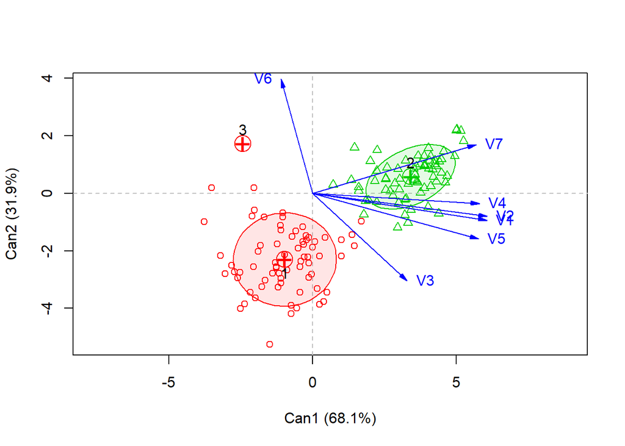

```r
plot(df.lda,ellipse = T)
```

Пусть $\mathbf Y$ — матрица данных. Матрица межгрупповых отклонений $\mathbf H = \sum_{i=1}^k n_i (\mathbf{\bar y_i - \bar y})(\mathbf{\bar y_i - \bar y})^\mathrm T$ , матрица $\mathbf E = \sum_{i=1}^k \sum_{j=1}^{n_i} (y_{ij} - \mathbf{ \bar y_i})(y_{ij} - \mathbf{ \bar y_i})^\mathrm T$.

$A_1,\ldots,A_s$ — собственные вектора $\mathbf{E^{-1}H}$, называемые дискриминантными функциями, $\lambda_i$ — упорядоченные по убыванию собственные числа. Канонические переменные — вектора данных в новых координатах $Z_i=\mathbf Y A_i$.

Задача: проинтепретировать канонические переменные (новые признаки).

Первый способ проинтерпретировать разложение по дискриминантным переменным — посмотреть на коэффициенты, с которыми исходные переменные входят в дискриминантные. Если исходные переменные измерены в различных шкалах, то коэффициенты в векторе $A_i$ одновременно ещё и приводят показатели к нужной шкале. Чтобы избежать этого эффекта, можно посмотреть на стандартизованные дискриминантные функции.

Пусть $\mathbf S$ – матрица взвешенных ковариаций (pooled covariance matrix), $s_1^2,\ldots,s_p^2$ – элементы ее диагонали (взвешенные дисперсии признаков, pooled variance). Тогда

$$Z_i = \mathbf Y A_i = \sum_{j=1}^p Y_j a_{ij} = \sum_{j=1}^p \frac{Y_j}{s_j} s_ja_{ij}$$

и $\tilde A_i = \text{diag}(\mathbf S)^{1/2} A_i$ – $i$-я стандартизованная дискриминантная функция (стд. д. ф.). Коэффициенты стд. д. ф. показывают вклады исходных признаков в дискриминантные переменные.

```r
df.lda$coeffs.std #stand. coef
```

```
##            Can1       Can2
## V1 -0.493771427  4.8882304
## V2  1.996977303 -4.4709101
## V3  0.106911806 -1.5688026
## V4 -1.314544983 -1.7190109
## V5  0.006335608  0.1221188
## V6 -0.055543999  0.3961115
## V7  0.720730952  1.5981090
```

Второй способ заключается в рассмотрении факторной структуры.

Факторная структура — матрица корреляций между исходными и каноническими переменными. Так как дискриминантные функции, вообще говоря, не ортогональны, то получатся другие числа. Что правильнее - сложный вопрос.

```r
df.lda$structure #Factor structure matrix
```

```
##          Can1        Can2
## V1  0.9778478 -0.15164382
## V2  0.9796335 -0.12948257
## V3  0.5305788 -0.49215665
## V4  0.9356385 -0.05690861
## V5  0.9316370 -0.25643941
## V6 -0.1773646  0.64189883
## V7  0.9171144  0.27437142
```

В данном случае factor structure кажется более осмысленной, так как она лучше интерпретируется (исходно все признаки, кроме шестого отвечали за размер зернышка, а шестой отвечал за форму).

#### Отсев признаков

stepclass производит отсев с помощью cross-validation. Интересно, как сильно отличаются результаты backward и forward (который совпадает с both) методов. Можно менять начальный набор признаков и параметр кросс-валидации (по умолчанию стоит 10)

```r
stepclass(df[,-8],df[,8],"lda",direction = "backward",fold = 30)
```

```
## correctness rate: 0.96667;  starting variables (7): V1, V2, V3, V4, V5, V6, V7
##
##  hr.elapsed min.elapsed sec.elapsed
##        0.00        0.00        4.45
```

```
## method      : lda
## final model : df[, 8] ~ V1 + V2 + V3 + V4 + V5 + V6 + V7
## <environment: 0x000000001e624a68>
##
## correctness rate = 0.9667
```

```r
stepclass(df[,-8],df[,8],"lda",direction = "forward",fold = 30)
```

```
## correctness rate: 0.87143;  in: "V1";  variables (1): V1
## correctness rate: 0.93333;  in: "V7";  variables (2): V1, V7
##
##  hr.elapsed min.elapsed sec.elapsed
##        0.00        0.00        6.98
```

```
## method      : lda
## final model : df[, 8] ~ V1 + V7
## <environment: 0x000000001d801198>
##
## correctness rate = 0.9333
```

greedy.wilks – forward variable selection. Значение F.statistics.diff - это аппроксимация partial Wilks’s lamda.

$$(\mathrm{Partial}\,\Lambda)_i = \frac{\Lambda(Y_1,\ldots,Y_p)}{\Lambda(Y_1,\ldots,\bar Y_i,\ldots,Y_p)} \sim \Lambda_1(k-1,n-k-p+1)$$

```r
greedy.wilks(X = df[,-c(8)],grouping = df[,8],niveau = 1)
```

```
## Formula containing included variables:
##
## df[, 8] ~ V1 + V7 + V4 + V6 + V3 + V2 + V5
## <environment: 0x000000001db4e048>
##
##
## Values calculated in each step of the selection procedure:
##
##   vars Wilks.lambda F.statistics.overall p.value.overall F.statistics.diff
## 1   V1   0.15881870             548.1865    1.964806e-83      548.18647869
## 2   V7   0.07856283             264.4757   2.406078e-112      105.21965349
## 3   V4   0.05395084             225.8605   1.349932e-126       46.75978495
## 4   V6   0.04589889             187.0505   2.263961e-131       17.89364374
## 5   V3   0.04203574             157.4235   5.914498e-133        9.32801654
## 6   V2   0.03530530             145.5095   2.300918e-138       19.25417535
## 7   V5   0.03528718             124.1442   3.184594e-136        0.05160107
##   p.value.diff
## 1 1.964806e-83
## 2 0.000000e+00
## 3 0.000000e+00
## 4 6.875930e-08
## 5 1.329112e-04
## 6 2.204116e-08
## 7 9.497202e-01
```

#### Полученная модель

```r
df.mod2 <- lm( cbind(V1,V7) ~ V8,data = df)
df.lda2 <- candisc(df.mod2,data = df)
summary(df.lda2)
```

```
##
## Canonical Discriminant Analysis for V8:
##
##    CanRsq Eigenvalue Difference Percent Cumulative
## 1 0.84388    5.40542     4.4182  84.558     84.558
## 2 0.49677    0.98717     4.4182  15.442    100.000
##
## Class means:
##
##       Can1     Can2
## 1 -0.66307 -1.36596
## 2  3.09967  0.43758
## 3 -2.43660  0.92838
##
##  std coefficients:
##       Can1    Can2
## V1 0.85222 -1.0085
## V7 0.20732  1.3040
```

Значения новых признаков

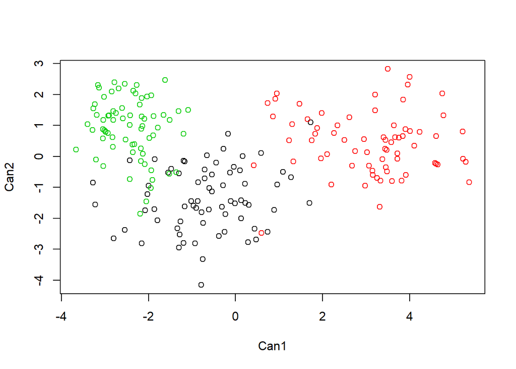

```r
plot(df.lda2$scores[,2:3],col=df$V8)
```

##### Классификация

Если всего два класса, то можно построить границу между классами, приравняв классифицирующие функции.

Исходя из предполагаемой модели ($\mathcal P(\eta|\xi=A_i)=\mathcal N(\mu_i,\Sigma)$) и априорных вероятностей можно построить разделяющую гиперплоскость.

Уравнение разделяющей гиперплоскости получится, если приравнять значения классифицирующих функций, и если идет предположение, что данные в групах удовлетворяют условию гомоскедаксичности, то функция будет линейной.

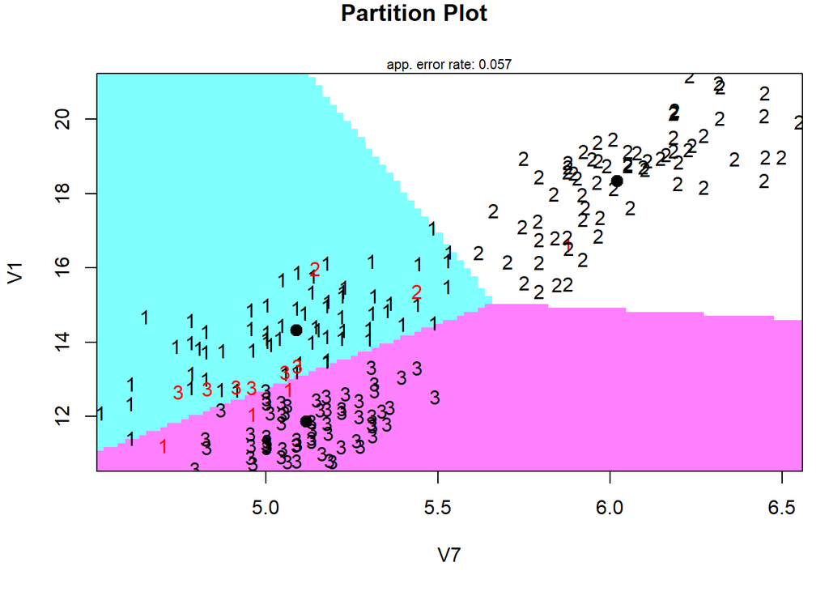

```r
partimat(V8 ~ V1 + V7, df, method="lda")
```

В случае $\mathcal P(\eta|\xi=A_i)=\mathcal N(\mu_i,\Sigma_i)$ получим, что поверхность имеет вид квадратичной поверхности.

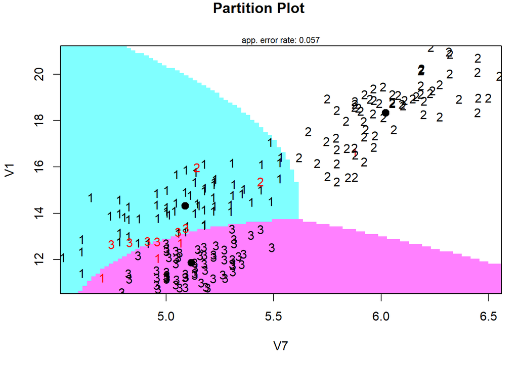

```r
partimat(V8 ~ V1 + V7, df, method = "qda")
```

##### ROC-кривые

(Информация с wiki)

> ROC-кривая (англ. receiver operating characteristic, рабочая характеристика приёмника) — график, позволяющий оценить качество бинарной классификации, отображает соотношение между долей объектов от общего количества носителей признака, верно классифицированных как несущих признак, (англ. true positive rate, TPR, называемой чувствительностью алгоритма классификации) и долей объектов от общего количества объектов, не несущих признака, ошибочно классифицированных как несущих признак (англ. false positive rate, FPR, величина 1-FPR называется специфичностью алгоритма классификации) при варьировании порога решающего правила. Также известна как кривая ошибок. Анализ классификаций с применением ROC-кривых называется ROC-анализом.

Если кто-то хорошо представляет себе, как выглядит график зависимости мощности от ошибки первого рода, то это именно такой график. Меняется уровень значимости (как порог отвергнуть - не отвергнуть) и по оси x откладывается ошибка первого рода, она же false positive, а по оси y откладывается мощность, она же true positive (слово positive означает, что нулевая гипотеза отвергнута в пользу второй, альтернативной, гипотезы, а в случае классификации, что элемент классифицируется как относящийся ко второму классу).

Таким образом, меняем порог для метода классификации и по оси x откладываем долю неправильно классифицированных элементов из первого класса, а по оси y — долю правильно классифицированных элементов из второго класса.

```r
library(pROC)
df.lda <- lda(df[,c(1,7)],df[,8],CV=T)
table(df.lda$class, df[,8])
```

```
##
##      1  2  3
##   1 64  2  6
##   2  2 68  0
##   3  4  0 64
```

При классификации мало ошибок и ROC-кривые должны быть очень хорошие (близки к 1).

По идее мы должны рассматривать бинарную классификацию, поэтому рассмотрим dummy-признак принадлежности первому классу.

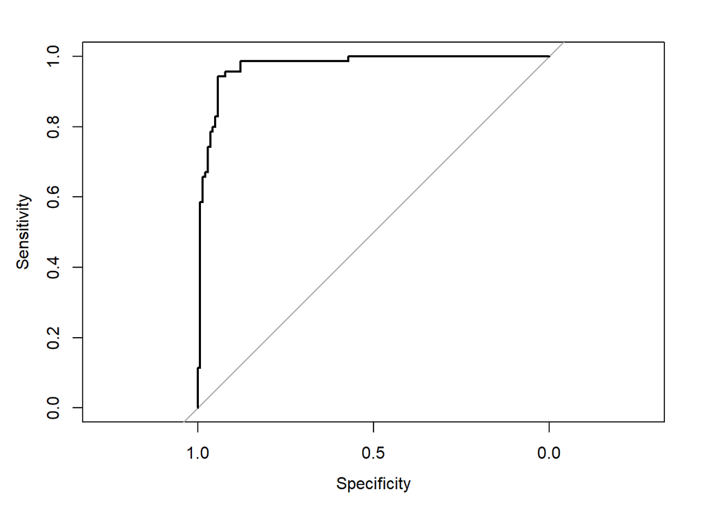

```
##
## Call:
## roc.default(response = df[, 8] == 1, predictor = df.lda$posterior[,     1], plot = T)
##
## Data: df.lda$posterior[, 1] in 140 controls (df[, 8] == 1 FALSE) < 70 cases (df[, 8] == 1 TRUE).
## Area under the curve: 0.9724
```

```r
roc(df[,8]==1,df.lda$posterior[,1],plot=T)
```